# My Circuit Library

Useful helper methods

Single Qubit Gates  
X gate rotates around the X axis  
Hadamard gate rotates around the X-Z axis

Single-qubit Gate equivalencies  
Z = HXH

Two Qubit Gates  
Controlled rotation around the Y axis

## Useful helper methods

```python
import warnings
warnings.filterwarnings('ignore')
from qiskit import QuantumCircuit
from math import pi
from qiskit import Aer, assemble, execute
from qiskit.visualization import plot_histogram, array_to_latex, plot_state_qsphere
from qiskit.visualization import plot_bloch_multivector
from numpy import angle, absolute
from numpy import arccos

def display_circuit(qc, title):
    print(qc.draw(output='mpl'), title)

def display_unitary_matrix(qc):
    sim = Aer.get_backend('aer_simulator')
    qc.save_unitary()
    qobj = assemble(qc)
    unitary = sim.run(qobj).result().get_unitary()
    display(array_to_latex(unitary, prefix="\\text{Circuit = } "))

def display_state_vector(qc):
    sim = Aer.get_backend('aer_simulator_statevector')
    qc.save_statevector()
    qobj = assemble(qc)
    result = sim.run(qobj).result()
    final_state = result.get_statevector()
    display(array_to_latex(final_state, prefix="\\text{Statevector = }"))

def display_histogram(qc, title):
    sim = Aer.get_backend('aer_simulator_statevector')
    qc.save_statevector()
    qobj = assemble(qc)
    result = sim.run(qobj).result()
    print(plot_histogram(result.get_counts()), title)

def display_q_sphere(qc, title):
    sim = Aer.get_backend('aer_simulator_statevector')
    qc.save_statevector()
    qobj = assemble(qc)
    result = sim.run(qobj).result()
    final_state = result.get_statevector()
    print(plot_state_qsphere(final_state), title)

def display_single_qubit(circuit_func, theta=0, phi=0, suppress_initial=False):
    import os
    import sys
    # Throw away anything written to standard output
    null_file = open(os.devnull, 'w')
    stdout_file = sys.stdout
    sys.stdout = null_file
    # Display the circuit
    qc = QuantumCircuit(1); circuit_func(qc)
    display_circuit(qc, '')
    # Display the unitary matrix representing the gate
    qc = QuantumCircuit(1); circuit_func(qc)
    display_unitary_matrix(qc)
    if not suppress_initial:
        # Display the initial state on the Bloch sphere
        qc = QuantumCircuit(1); qc.u(theta, phi, 0, 0)
        display_bloch(qc, '', 'Initial statevector')
    # Display the Bloch sphere
    qc = QuantumCircuit(1); qc.u(theta, phi, 0, 0); circuit_func(qc)
    display_bloch(qc, '', 'Final statevector')
    # Restore the standard output
    sys.stdout = stdout_file

def display_two_qubits(setup_func, circuit_func):
    import os
    import sys
    # Throw away anything written to standard output
    null_file = open(os.devnull, 'w')
    stdout_file = sys.stdout
    sys.stdout = null_file
    # Display the circuit
    qc = QuantumCircuit(2); circuit_func(qc)
    display_circuit(qc, '')
    # Display the unitary matrix representing the gate
    qc = QuantumCircuit(2); circuit_func(qc)
    display_unitary_matrix(qc)
    # Run the entire circuit and display the state vector and Q Sphere
    qc = QuantumCircuit(2)
    setup_func(qc)
    circuit_func(qc)
    sim = Aer.get_backend('statevector_simulator')
    qobj = assemble(qc)
    result = sim.run(qobj).result()
    out_state = result.get_statevector()
    display(array_to_latex(out_state, prefix="\\text{Statevector = }"))
    plot_state_qsphere(out_state)
    plot_histogram(result.get_counts())
    # Restore the standard output
    sys.stdout = stdout_file

def state_vector_to_angles_and_ampls(v):
    a = v[0]
    b = v[1]
    phi = round((angle(b) - angle(a)) * 180. / pi, 1)
    theta = round(2 * arccos(absolute(a)) * 180. / pi, 1)
    return theta, phi, absolute(a), absolute(b)

def display_bloch(qc, title, statevector_text='Statevector'):
    sim = Aer.get_backend('statevector_simulator')
    qobj = assemble(qc)
    result = sim.run(qobj).result()
    out_state = result.get_statevector()
    theta, phi, a_amp, b_amp = state_vector_to_angles_and_ampls(out_state)
    print(plot_bloch_multivector(out_state, reverse_bits=True), title)
    if len(out_state) == 2:
        latex_prefix = "\\text{" + statevector_text + " for θ = " + str(theta) + "°, φ = " + str(phi) + "°, |a|² = " + \
            str(round(a_amp*a_amp, 3)) + ", |b|² = " + str(round(b_amp*b_amp, 3)) + " = }"
        display(array_to_latex(out_state, prefix=latex_prefix))

def one_qubit_circuit():
    return QuantumCircuit(1)

def two_qubit_circuit():
    return QuantumCircuit(2)
```

## Single Qubit Gates

### X gate rotates around the X axis

First, state in state [1, 0]:

```python
display_single_qubit(lambda qc: qc.x(0), 0, 0)
```

$$ \text{Circuit = } \begin{bmatrix} 0 & 1 \\ 1 & 0 \\ \end{bmatrix} $$

$$ \text{Initial statevector for θ = 0.0°, φ = 0.0°, |a|² = 1.0, |b|² = 0.0 = } \begin{bmatrix} 1 & 0 \\ \end{bmatrix} $$

$$ \text{Final statevector for θ = 180.0°, φ = 0.0°, |a|² = 0.0, |b|² = 1.0 = } \begin{bmatrix} 0 & 1 \\ \end{bmatrix} $$

Next, start at θ = 90°, φ = 90°:

$$ \text{Circuit = } \begin{bmatrix} 0 & 1 \\ 1 & 0 \\ \end{bmatrix} $$

$$ \text{Initial statevector for θ = 90.0°, φ = 90.0°, |a|² = 0.5, |b|² = 0.5 = } \begin{bmatrix} \tfrac{1}{\sqrt{2}} & \tfrac{1}{\sqrt{2}}i \\ \end{bmatrix} $$

$$ \text{Final statevector for θ = 90.0°, φ = -90.0°, |a|² = 0.5, |b|² = 0.5 = } \begin{bmatrix} \tfrac{1}{\sqrt{2}}i & \tfrac{1}{\sqrt{2}} \\ \end{bmatrix} $$

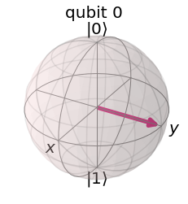

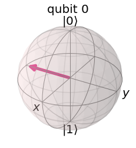

```python
display_single_qubit(lambda qc: qc.x(0), pi/2, pi/2)
```

Finally, if initial state points along the x axis, there is no change:

```python
display_single_qubit(lambda qc: qc.x(0), pi/2, 0)
```

$$ \text{Circuit = } \begin{bmatrix} 0 & 1 \\ 1 & 0 \\ \end{bmatrix} $$

$$ \text{Initial statevector for θ = 90.0°, φ = 0.0°, |a|² = 0.5, |b|² = 0.5 = } \begin{bmatrix} \tfrac{1}{\sqrt{2}} & \tfrac{1}{\sqrt{2}} \\ \end{bmatrix} $$

$$ \text{Final statevector for θ = 90.0°, φ = 0.0°, |a|² = 0.5, |b|² = 0.5 = } \begin{bmatrix} \tfrac{1}{\sqrt{2}} & \tfrac{1}{\sqrt{2}} \\ \end{bmatrix} $$

### Hadamard gate rotates around the X-Z axis

This has the effect of entangling (or disentangling) the qubit. In effect, the |0> and |1> amplitudes are modified.

With the initial state of θ = 22.5°, φ = 0°:

$$ \text{Circuit = } \begin{bmatrix} \tfrac{1}{\sqrt{2}} & \tfrac{1}{\sqrt{2}} \\ \tfrac{1}{\sqrt{2}} & -\tfrac{1}{\sqrt{2}} \\ \end{bmatrix} $$

$$ \text{Initial statevector for θ = 22.5°, φ = 0.0°, |a|² = 0.962, |b|² = 0.038 = } \begin{bmatrix} 0.98079 & 0.19509 \\ \end{bmatrix} $$

$$ \text{Final statevector for θ = 67.5°, φ = 0.0°, |a|² = 0.691, |b|² = 0.309 = } \begin{bmatrix} 0.83147 & 0.55557 \\ \end{bmatrix} $$

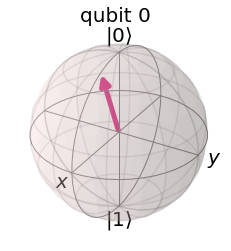

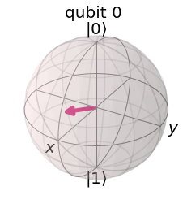

```python
display_single_qubit(lambda qc: qc.h(0), pi / 8, 0)
```

## Single-qubit Gate equivalencies

### Z = HXH

First note that Z rotates 180° around the Z axis. In this example, we start in an entangled state pointing along the X axis and apply the H gate:

```python
display_single_qubit(lambda qc: qc.h(0), pi / 2, 0)
```

$$ \text{Circuit = } \begin{bmatrix} \tfrac{1}{\sqrt{2}} & \tfrac{1}{\sqrt{2}} \\ \tfrac{1}{\sqrt{2}} & -\tfrac{1}{\sqrt{2}} \\ \end{bmatrix} $$

$$ \text{Initial statevector for θ = 90.0°, φ = 0.0°, |a|² = 0.5, |b|² = 0.5 = } \begin{bmatrix} \tfrac{1}{\sqrt{2}} & \tfrac{1}{\sqrt{2}} \\ \end{bmatrix} $$

$$ \text{Final statevector for θ = 0.0°, φ = 90.0°, |a|² = 1.0, |b|² = 0.0 = } \begin{bmatrix} 1 & 0 \\ \end{bmatrix} $$

Next we rotate around the X axis:

```python
display_single_qubit(lambda qc: (qc.h(0), qc.x(0)),
                     pi / 2, 0, suppress_initial=True)
```

$$ \text{Circuit = } \begin{bmatrix} \tfrac{1}{\sqrt{2}} & -\tfrac{1}{\sqrt{2}} \\ \tfrac{1}{\sqrt{2}} & \tfrac{1}{\sqrt{2}} \\ \end{bmatrix} $$

$$ \text{Final statevector for θ = 180.0°, φ = -90.0°, |a|² = 0.0, |b|² = 1.0 = } \begin{bmatrix} 0 & 1 \\ \end{bmatrix} $$

Finally, another Hadamard is applied:

$$ \text{Circuit = } \begin{bmatrix} 1 & 0 \\ 0 & -1 \\ \end{bmatrix} $$

$$ \text{Final statevector for θ = 90.0°, φ = 180.0°, |a|² = 0.5, |b|² = 0.5 = } \begin{bmatrix} \tfrac{1}{\sqrt{2}} & -\tfrac{1}{\sqrt{2}} \\ \end{bmatrix} $$

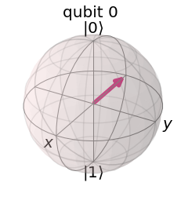

```python
display_single_qubit(lambda qc: (qc.h(0), qc.x(0), qc.h(0)),
                     pi / 2, 0, suppress_initial=True)
```

## Two Qubit Gates

### Controlled rotation around the Y axis

First, let's apply the Y gate to various θ angles (0°, 45°, 90°, 135°, 180°, 225°, and 315°). Interestingly, the resultant φ angles are 90°, 180°, 180°, 180°, 180°, 0°, and 0°, respectively. It seems that except for an initial angle of 0, the φ angle is 180° if the resultant vector ends up in the rear half of the sphere and 0° if the resultant vector ends up in the front half of the sphere.

```python
display_single_qubit(lambda qc: (qc.y(0)), 0, 0, suppress_initial=True)
```

$$ \text{Circuit = } \begin{bmatrix} 0 & -i \\ i & 0 \\ \end{bmatrix} $$

$$ \text{Final statevector for θ = 180.0°, φ = 90.0°, |a|² = 0.0, |b|² = 1.0 = } \begin{bmatrix} 0 & i \\ \end{bmatrix} $$

$$ \text{Circuit = } \begin{bmatrix} 0 & -i \\ i & 0 \\ \end{bmatrix} $$

$$ \text{Final statevector for θ = 135.0°, φ = 180.0°, |a|² = 0.146, |b|² = 0.854 = } \begin{bmatrix} -0.38268i & 0.92388i \\ \end{bmatrix} $$

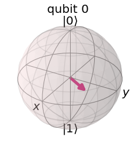

```python
display_single_qubit(lambda qc: (qc.y(0)), pi / 4, 0, suppress_initial=True)
```

$$ \text{Circuit = } \begin{bmatrix} 0 & -i \\ i & 0 \\ \end{bmatrix} $$

$$ \text{Final statevector for θ = 90.0°, φ = 180.0°, |a|² = 0.5, |b|² = 0.5 = } \begin{bmatrix} -\tfrac{1}{\sqrt{2}}i & \tfrac{1}{\sqrt{2}}i \\ \end{bmatrix} $$

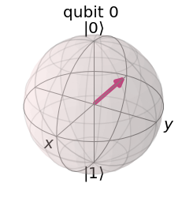

```python
display_single_qubit(lambda qc: (qc.y(0)), pi / 2, 0, suppress_initial=True)
```

$$ \text{Circuit = } \begin{bmatrix} 0 & -i \\ i & 0 \\ \end{bmatrix} $$

$$ \text{Final statevector for θ = 45.0°, φ = 180.0°, |a|² = 0.854, |b|² = 0.146 = } \begin{bmatrix} -0.92388i & 0.38268i \\ \end{bmatrix} $$

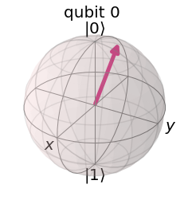

```python
display_single_qubit(lambda qc: (qc.y(0)), 3 * pi / 4, 0, suppress_initial=True)
```

```python
display_single_qubit(lambda qc: (qc.y(0)), pi, 0, suppress_initial=True)
```

$$ \text{Circuit = } \begin{bmatrix} 0 & -i \\ i & 0 \\ \end{bmatrix} $$

$$ \text{Final statevector for θ = 0.0°, φ = 180.0°, |a|² = 1.0, |b|² = 0.0 = } \begin{bmatrix} -i & 0 \\ \end{bmatrix} $$

$$ \text{Circuit = } \begin{bmatrix} 0 & -i \\ i & 0 \\ \end{bmatrix} $$

$$ \text{Final statevector for θ = 45.0°, φ = 0.0°, |a|² = 0.854, |b|² = 0.146 = } \begin{bmatrix} -0.92388i & -0.38268i \\ \end{bmatrix} $$

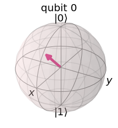

```python
display_single_qubit(lambda qc: (qc.y(0)), 5 * pi /4, 0, suppress_initial=True)
```

$$ \text{Circuit = } \begin{bmatrix} 0 & -i \\ i & 0 \\ \end{bmatrix} $$

$$ \text{Final statevector for θ = 135.0°, φ = 0.0°, |a|² = 0.146, |b|² = 0.854 = } \begin{bmatrix} -0.38268i & -0.92388i \\ \end{bmatrix} $$

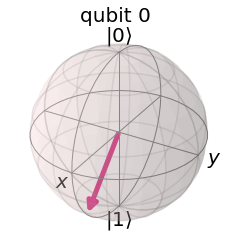

```python
display_single_qubit(lambda qc: (qc.y(0)), 7 * pi /4, 0, suppress_initial=True)
```

An arbitrary controlled rotation around the Y axis can be built from more basic gates. Both control and target bits start in the entangled state.

$$ \text{Circuit = } \begin{bmatrix} 1 & 0 & 0 & 0 \\ 0 & 0 & 0 & -1 \\ 0 & 0 & 1 & 0 \\ 0 & 1 & 0 & 0 \\ \end{bmatrix} $$

$$ \text{Statevector = } \begin{bmatrix} \tfrac{1}{2} & -\tfrac{1}{2} & \tfrac{1}{2} & \tfrac{1}{2} \\ \end{bmatrix} $$

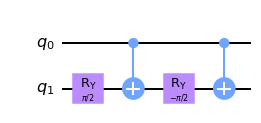

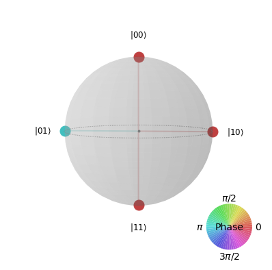

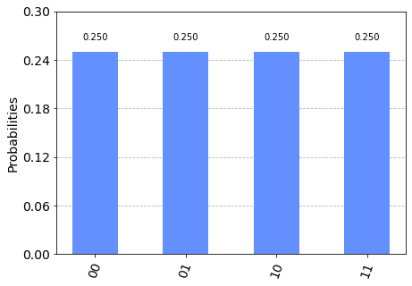

```python
theta = pi
c = 0  # control qubit
t = 1  # target qubit
display_two_qubits(lambda qc: (qc.h(0), qc.h(1)),
                   lambda qc: (qc.ry(theta/2,t), qc.cx(c,t), qc.ry(-theta/2,t),
                               qc.cx(c,t)))
```

If the control qubit is in the state |0>, the Y axis rotations are reversed, and nothing happens. This corresponds to the resultant states |00> and |10>. If, on the other hand, the control bit is in the state |1>, a flip around the Y axis occurs. As can be seen in the statevector, state |01> is offset from |11> by 180°. This makes sense from the previous single Y gate results, since the Y gate applied to an entangled state (θ = 90°, φ = 0°) results in the final state of θ = 90°, φ = 180°.